## Introduction

Based on our understanding of your requirements, which is to estimate scores for children who took the Parent-Child Internet Addiction Test (PCIAT) based on features such as Sleep Distance Score, Internet use, Age, and Sex. This report examines whether linear regression or k-Nearest Neighbors provides the best predictive accuracy for estimating scores for children not present in this data set. The following sections outline the steps taken to achieve this objective. Section 1 presents the exploratory data analysis, introducing the model selection process. Given that this is a prediction task, linear regression and k-Nearest Neighbors are both suitable choices. This section also includes the linear regression model we developed, along with the assumptions of linear regression, which the dataset meets. In Section 1.2, we present the trained regression model, and Section 1.3 provides an evaluation of the model using Root Mean Squared Error (RMSE), derived via 10-fold cross-validation. Section 2 covers the use of k-Nearest Neighbors (KNN) as an alternative method to predict PCIAT scores based on the available features, testing values of K in the range of 3 to 51. Finally, Section 3 details our conclusions after comparing KNN and linear regression models. In this report: PCIAT refers to the Parent-Child Internet Addiction Test, SleepDistScore indicates how much a child’s sleep is disturbed on a typical night, InternetUse reflects the child’s typical daily internet usage hours, Age denotes the child’s age in years, and Sex indicates the child’s gender.

## Section 1: Linear Regression

This section will explore the predictive abilities of linear regression. Specifically, this section will contain a linear regression model using all possible features to predict the PCIAT score.

### 1.1 Exploratory Data Analysis

This section shows the exploratory data analysis of the data set. Before we proceed to fit a linear regression model on the PCIAT variable, we perform some exploratory data analysis of the response variable and features. We also check for missing variables within the data set.

Summary of Dataset

| Age | SleepDistScore |
| --- | --- |
| Min. : 5.00 | Min. : 38.00 |
| 1st Qu.: 8.00 | 1st Qu.: 49.00 |
| Median :10.00 | Median : 55.00 |
| Mean :10.34 | Mean : 57.98 |
| 3rd Qu.:12.00 | 3rd Qu.: 66.00 |
| Max. :22.00 | Max. :100.00 |

From Table 1, it is noted that the age of the students ranged from 5 to 22, and the minimum SleepDistScore score is 38 with a maximum of 100. Examining the data set for the presence of missing variables revealed that there are no missing variables (see Figure 1.1). The black spaces, which would typically indicate missing data, are absent in the figure, confirming that the is data complete, and we can proceed to evaluate the relationship between the different features and the response variable.

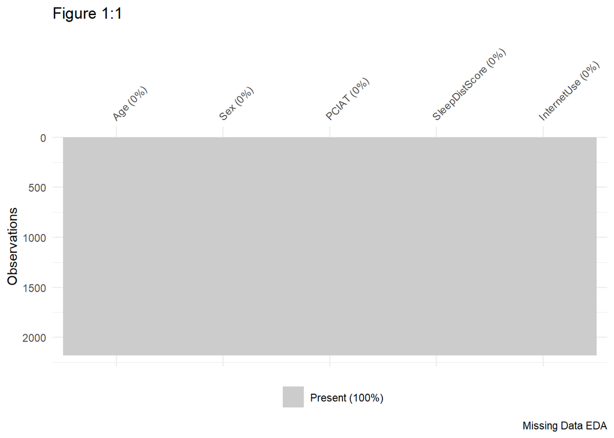

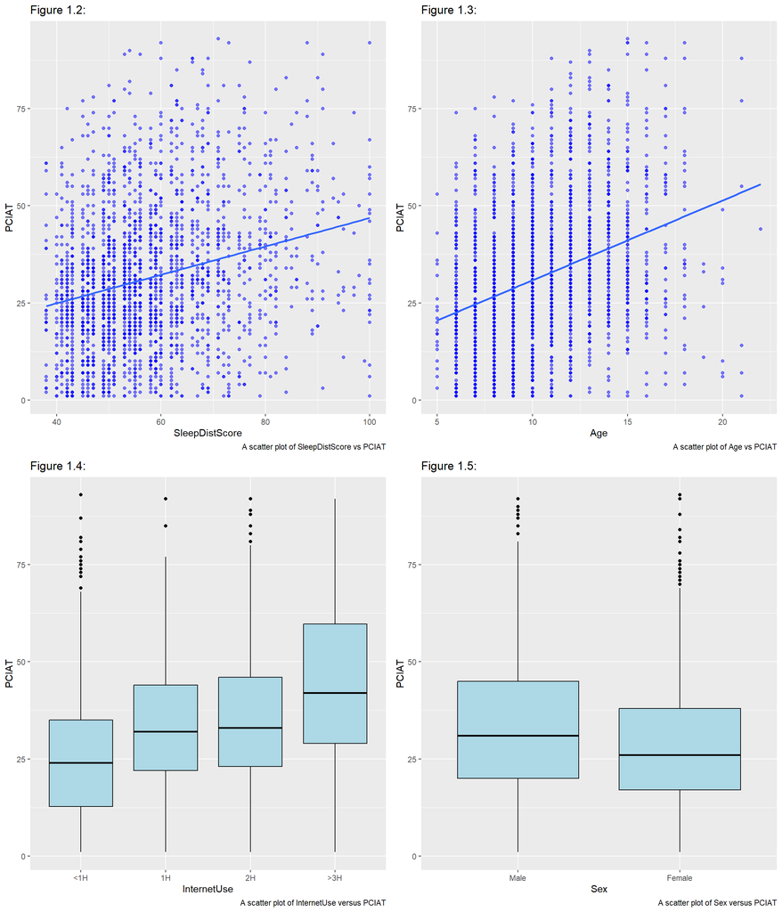

### 1.2 Least Squared Linear Regression Model

In this section, we proceed to fit a linear regression model to the data set, using all possible features to predict the PCIAT score. The general model for linear regression is given by:

$$y = \beta_0 + \beta_1 X + \beta_2 X +
\beta_3 X + \beta_4 X + \epsilon.0, \epsilon
\overset{\text{i.i.d.}}{\sim} N(0, \sigma)$$

Training the model:

$$PCIAT_i = \beta_0 + \beta_1 Age_i +
\beta_2 Sex_i + \beta_3 SleepDistScore_i + \beta_4InternetUse_i +
\epsilon_i, \epsilon_i \overset{\text{iid}}{\sim} N(0, \sigma)$$

Here, PCIAT is Parent-Child Internet Addiction Test Score, SleepDistScore is a numeric measure of how much the child’s sleep is disturbed on a typical night, InternetUse is a score indicating how many hours a day the child typically spends on the Internet, Age is the age of the child in years and Sex is indicator for the sex of the child. 0 = male, 1 = female.

The Trained (Fitted) Model is given by:

$$\widehat{PCIAT_i} = -6.8438 +
1.6117Age_i + -4.6467Sex_i + 0.3382 SleepDistScore_i +
3.5285 InternetUse_i$$

From the model above, the intercept is $-6.84$, the intercept suggests a negative baseline PCIAT score when all features are zero. The p-value of the intercept (0.000569) is less than 0.05, indicating that the intercept is statistically significant in predicting PCIAT scores. Age has a positive coefficient of 1.62, meaning that for every 1-year increase in age, the PCIAT score on average increases by approximately 1.62 points, implying that older children are more likely to have higher levels of internet addiction. Furthermore, the p-value for Age ($2 \times e^{-16}$) is less than 0.05, indicating that Age is statistically significant. Sex has a negative coefficient of 4.65, meaning that females have, on average, 4.65 points lower PCIAT scores compared to males. Additionally, the p-value for Sex ($2.31\times e^{-10}$) is less than 0.05, indicating that Sex is statistically significant. SleepDistScore has a positive relationship with PCIAT of 0.34; for every 1-point increase in SleepDistScore, the PCIAT score on average increases by approximately 0.34 points, suggesting that poorer sleep quality is linked to higher levels of internet addiction. The p-value for SleepDistScore ($2 \times e^{-16}$) is also less than 0.05, indicating that this predictor is significant. InternetUse also shows a positive relationship with PCIAT; for every 1-level increase in InternetUse (i.e., moving from a lower category of internet use to a higher one), the PCIAT score on average increases by approximately 3.53 points, suggesting that increased internet usage is associated with higher levels of compulsive behavior. The p-value for InternetUse ($2\times e^{-16}$) is less than 0.05, indicating that this predictor is statistically significant. The R-squared value of the model is 0.232, meaning that the model above explains 23.2% of the variation in PCIAT scores. All the predictors have very p-values less than 0.05 showing that each feature included in the model significantly contributes to predicting PCIAT scores.

|  | Coeffients | P_value | Statistical Significance |
| --- | --- | --- | --- |
| Intercept | -6.8438 | 0.000569 | Significant |
| Age | 1.6117 | $2 \times e^-16$ | Significant |
| Sex | -4.6467 | $2.31 \times e^-10$ | Significant |
| SleepDistScore | 0.3382 | $2 \times e^-16$ | Significant |
| InternetUse | 3.5285 | $2 \times e^-16$ | Significant |

### 1.3 10 -fold CV

In this section, we will discuss how well the model would be able to predict the PCIAT score for a new child who had not yet taken the test, specifically. In order to assess the predictive abilities of the linear model, $10$-fold Cross Validation will be used. The reason for selecting this model can be explained by the need to have two sets of data (the training data set and test data set). Having two different data sets is very important in predictive modeling, as we use the training data set to conduct EDA, choose and build our models, and we use the testing (test) data set to evaluate how well our model can perform predictions. There are various techniques for creating test data when test data is not available. Three commonly used methods of splitting the data set into a fraction for training and another fraction for testing are: splitting the data into training and validation data, Leave-One-Out Cross Validation (LOOCV), and $k$-fold Cross Validation. The reason the latter two are preferred over the first method is that splitting the data into training and validation data involves creating validation data from the single data set we have. This can be done by taking some of the rows from the training set and putting them in a separate data set, which is then declared as validation data. This technique has several drawbacks, such as reducing our sample size and making the results highly dependent on which rows of the training data end up in the training and validation sets. Given these challenges, we consider other methods, specifically $k$-fold Cross Validation. The $k$-fold Cross Validation creates a validation data that does not depend on a process of separating in to two large subsets and does not result in a reduction in the size of our training data set. In this method, we create $k$ validation sets, where each of the $k$ validation sets is called a fold. We create these folds by randomly dividing the data into $k$ groups of approximately equal size. We start by treating fold 1 as the new validation set and the remaining $k-1$ folds as the new training data, and then repeat the process with the remaining folds. For this analysis, our choice of $k = 10$ is based on studies that have shown this tends to provide validation RMSE values that are neither highly biased nor have excessively large variance.

The Root Mean Squared Error (RMSE) is a measure of the average magnitude of the error between the predicted values and the actual observed values. Lower RMSE values indicate a better fit of the model to the data. The mathematical expression for the RMSE is given below:

$$\text{RMSE} = \sqrt{\frac{1}{n_{test}} \sum_{i^* = 1}^{n_{{test}}}
\left( y_{i^*} - \hat{y}_{i^*} \right)^2}$$

where $y$ represents the true values of the response variable, and $\hat{y}$ denotes the predicted values.

[figure not shown]

## Section 2: KNN

In this section, we will consider K-nearest neighbors as a second approach to estimate scores for children who took the Parent-Child Internet Addiction Test (PCIAT). K-nearest neighbors (KNN) is a predictive algorithm. Unlike a regression model, it does not require parameters or a mathematical equation to define it, making it a more flexible approach than regression. KNN looks at all rows in the training data set and finds the K rows that are most similar to a given row in the test data. To obtain the predicted PCIAT score for a row in the test set, KNN averages the PCIAT scores for these K rows in the training data.

KNN has three steps for every row in the test data:

- Step 1: Compute distance measures to determine how similar the row in the test data set is to all rows in the training data set. The disstance measure we would utilize for this analysis is the Euclidean Distance.
- Step 2: Find the K = K rows in the training data set that are closest (in terms of the chosen distance measure) to the row in the test set. These are called the three nearest neighbors in the training data to the test row.
- Step 3: Make a prediction for Y for the row in the test set using the average value of Y for its K = K nearest neighbors.

Choosing a value like K, which we get to set in order to optimize a certain measure, is called tuning. Because of this, K is called a tuning parameter. For this analysis, you have communicated that K values between 3 and 51 should be considered. It should be noted, however, that for large data sets we typically use $k = \sqrt{n}$, while for smaller data sets, we explore a range of options. The various Root Mean Squared Errors for the different levels of K are given in Table 3 below:

KNN RMSE Table: Showing the RMSE for different values of K

| K Value (KNN) | Root Mean Square Error (RMSE) |
| --- | --- |
| 3 | 17.8434 |
| 4 | 17.5856 |
| 5 | 17.3543 |
| 6 | 17.2108 |
| 7 | 17.1084 |
| 8 | 17.0187 |
| 9 | 16.9818 |
| 10 | 16.8807 |
| 11 | 16.8754 |
| 12 | 16.8646 |
| 13 | 16.8397 |
| 14 | 16.7963 |
| 15 | 16.7693 |
| 16 | 16.7534 |
| 17 | 16.7369 |
| 18 | 16.7230 |
| 19 | 16.7103 |
| 20 | 16.6882 |
| 21 | 16.6880 |
| 22 | 16.6947 |
| 23 | 16.6896 |
| 24 | 16.6817 |
| 25 | 16.6732 |
| 26 | 16.6690 |
| 27 | 16.6718 |
| 28 | 16.6635 |
| 29 | 16.6538 |
| 30 | 16.6748 |
| 31 | 16.6565 |
| 32 | 16.6346 |
| 33 | 16.6354 |
| 34 | 16.6270 |
| 35 | 16.6271 |
| 36 | 16.6230 |
| 37 | 16.6172 |
| 38 | 16.6160 |
| 39 | 16.6253 |
| 40 | 16.6242 |
| 41 | 16.6069 |
| 42 | 16.6105 |
| 43 | 16.6001 |
| 44 | 16.5990 |
| 45 | 16.6049 |
| 46 | 16.5985 |
| 47 | 16.5765 |
| 48 | 16.5764 |
| 49 | 16.5758 |
| 50 | 16.5789 |
| 51 | 16.5731 |

[figure not shown]

## Section 3: Conclusion

The objective of this study is to determine the most effective predictive model for estimating scores on the Parent-Child Internet Addiction Test (PCIAT) based on features such as: Sleep Distance Score, Internet use, Age, and Sex. We considered two models: linear regression and K-Nearest Neighbors (KNN). Linear Regression model first employed as it offered the advantage of being easy to interpret and it highlights the statistical significance of each predictor. All predictors (Age, Sex, SleepDistScore, and InternetUse) were statistically significant as $\alpha$ = 0.05. The KNN model was optimal at a K = 51, achieving an RMSE of 16.5731. In conclusion, the analysis reveals that the Linear Regression model outperforms the K-Nearest Neighbors (KNN) model in the prediction of PCIAT scores, achieving the lower RMSE of 16.3336. The results indicate that, on average, the predicted Parent-Child Internet Addiction Test (PCIAT) scores are approximately 16.3336 away from the true values. However, given the range of PCIAT scores (1 to 93) and the model’s Adjusted R-squared of 23.2%, the Linear Regression model captures only a limited portion of the variance in PCIAT scores. These results suggest that while Linear Regression offers better predictive accuracy between the two models being compared even after considering additional values of K. I would recommend the use of Linear regression, I would also recommend exploring other regression methods and machine learning algorithms for improved predictive performance.

## Appendix

Appendix I: Linear Regression Coefficients

| term | estimate | std.error | statistic | p.value |
| --- | --- | --- | --- | --- |
| (Intercept) | -6.8437560 | 1.9830833 | -3.451068 | 0.000569 |
| Age | 1.6117385 | 0.1223587 | 13.172246 | 0.000000 |
| Sex | -4.6466743 | 0.7295572 | -6.369170 | 0.000000 |
| SleepDistScore | 0.3382053 | 0.0268159 | 12.612103 | 0.000000 |
| InternetUse | 3.5285177 | 0.3528941 | 9.998799 | 0.000000 |

Appendix II: RMSE for KNN with k > 51

KNN RMSE Table: Showing the RMSE for K > 51

| K Value (KNN) | Root Mean Square Error (RMSE) |
| --- | --- |
| 52 | 16.5658 |
| 53 | 16.5677 |
| 54 | 16.5720 |
| 55 | 16.5637 |
| 56 | 16.5643 |
| 57 | 16.5659 |
| 58 | 16.5686 |
| 59 | 16.5661 |
| 60 | 16.5683 |
| 61 | 16.5545 |
| 62 | 16.5577 |
| 63 | 16.5633 |
| 64 | 16.5659 |
| 65 | 16.5709 |
| 66 | 16.5651 |
| 67 | 16.5627 |
| 68 | 16.5698 |
| 69 | 16.5691 |
| 70 | 16.5687 |
| 71 | 16.5878 |
| 72 | 16.5816 |
| 73 | 16.5758 |
| 74 | 16.5828 |
| 75 | 16.5856 |
| 76 | 16.5882 |
| 77 | 16.5910 |
| 78 | 16.5896 |
| 79 | 16.5873 |
| 80 | 16.5868 |
| 81 | 16.5846 |
| 82 | 16.5889 |
| 83 | 16.5937 |
| 84 | 16.5971 |
| 85 | 16.5941 |
| 86 | 16.5916 |
| 87 | 16.5848 |
| 88 | 16.5907 |
| 89 | 16.5937 |
| 90 | 16.5919 |
| 91 | 16.5949 |
| 92 | 16.6002 |
| 93 | 16.6104 |
| 94 | 16.6098 |
| 95 | 16.6061 |
| 96 | 16.6057 |
| 97 | 16.6054 |
| 98 | 16.6005 |
| 99 | 16.5953 |
| 100 | 16.5942 |